# Bank Marketing Campaign — Support Vector Machines

Assignment 3: SVM Classification with Linear and RBF Kernels

Sheriann McLarty

December 05, 2025

# 1 Executive Overview

This report extends the prior Bank Marketing classification work by introducing Support Vector Machines (SVM) as the next major modeling strategy. After exploring tree-based methods in Assignments 1 and 2 — including Decision Trees, Random Forest, and AdaBoost — this phase evaluates how SVM performs on the same prediction task: identifying clients who will subscribe to a term deposit.

Two kernels are tested: **linear** and **RBF**. Their performance is compared against previous models using ROC-AUC and PR-AUC metrics. The report also synthesizes insights from five academic articles that compare SVM and tree-based algorithms in healthcare and public health modeling. Together, these analyses help determine when SVM is the best tool — and when interpretability or operational constraints make tree-based models more practical.

**Related Work:**

- [Assignment 1 – Bank Marketing Campaign EDA](http://rpubs.com/SheriannMc/1352278)
- [Assignment 2 – Decision Trees, Random Forest, and AdaBoost](http://rpubs.com/SheriannMc/1377143)

# 2 Introduction

Support Vector Machines are powerful classifiers designed to find optimal decision boundaries. They are especially effective in high-dimensional spaces and are known for solid performance on imbalanced or complex datasets. In public health, SVMs have been widely used for disease detection, risk stratification, and early warning systems — often outperforming simpler models when tuned correctly.

In this assignment, SVM is applied to the same bank marketing dataset used in previous homework. The goal is not just to measure accuracy, but to evaluate:

- How SVM compares to tree-based learners,
- Whether kernel choice meaningfully changes results,
- And how SVM findings align with academic literature in healthcare analytics.

# 3 Data Preparation

```r
# Load dataset using correct separator
bank <- read.csv("bank.csv", sep = ";")

# Recode target as factor (0/1)
data <- bank %>%
  mutate(
    y = ifelse(y == "yes", 1, 0),
    y = factor(y)
  )

# Partitioning
set.seed(5286)
trainIndex <- createDataPartition(data$y, p = 0.8, list = FALSE)
train <- data[trainIndex, ]
test  <- data[-trainIndex, ]
```

# 4 Model Training and Tuning

## 4.1 Linear Kernel SVM

```r
set.seed(5286)

tune_linear <- tune.svm(
  y ~ .,
  data = train,
  kernel = "linear",
  cost = c(0.01, 0.1, 1, 10, 100),
  tunecontrol = tune.control(sampling = "cross", cross = 5)
)

# Display tuning results
print(tune_linear)
```

```
##
## Parameter tuning of 'svm':
##
## - sampling method: 5-fold cross validation
##
## - best parameters:
##  cost
##    10
##
## - best performance: 0.1053338
```

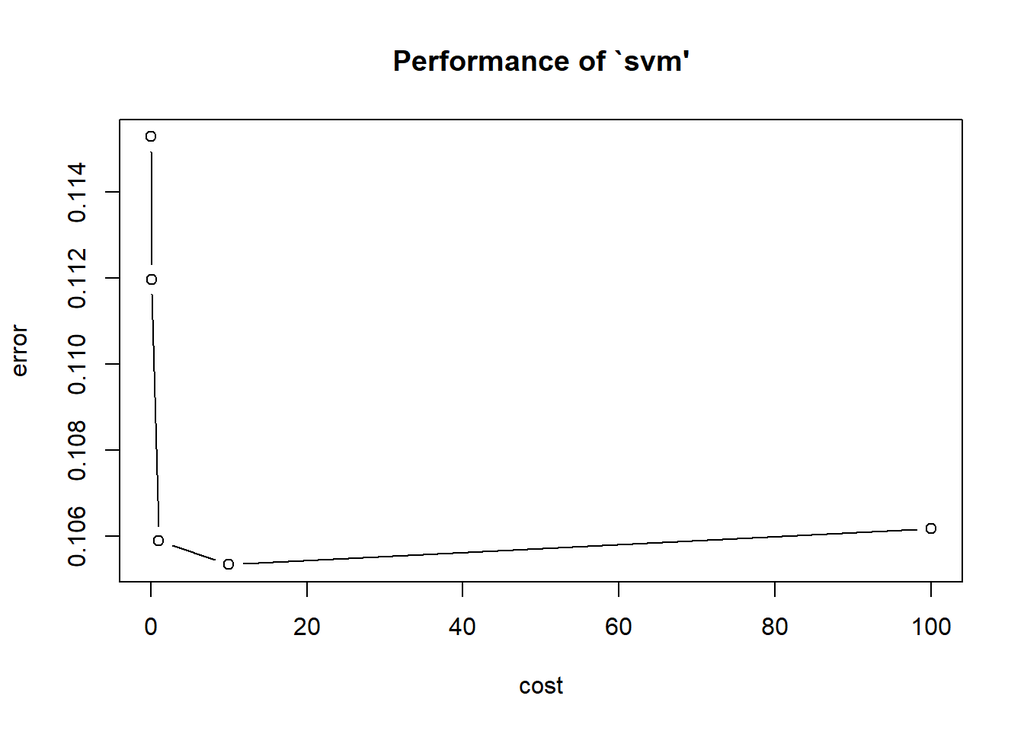

```r
plot(tune_linear)
```

```r
# Best parameters
cat("\nBest cost for Linear SVM:", tune_linear$best.parameters$cost, "\n")
```

```
##
## Best cost for Linear SVM: 10
```

```r
# Train final Linear SVM with best parameters
svm_linear <- tune_linear$best.model

# Predictions
pred_linear <- predict(svm_linear, newdata = test)
pred_linear_f <- factor(pred_linear, levels = levels(test$y))
test_y_f <- factor(test$y, levels = levels(test$y))

# Confusion Matrix
cm_linear <- confusionMatrix(pred_linear_f, test_y_f)
print(cm_linear)
```

```
## Confusion Matrix and Statistics
##
##           Reference
## Prediction   0   1
##          0 788  79
##          1  12  25
##
##                Accuracy : 0.8993
##                  95% CI : (0.8778, 0.9182)
##     No Information Rate : 0.885
##     P-Value [Acc > NIR] : 0.09456
##
##                   Kappa : 0.3131
##
##  Mcnemar's Test P-Value : 4.559e-12
##
##             Sensitivity : 0.9850
##             Specificity : 0.2404
##          Pos Pred Value : 0.9089
##          Neg Pred Value : 0.6757
##              Prevalence : 0.8850
##          Detection Rate : 0.8717
##    Detection Prevalence : 0.9591
##       Balanced Accuracy : 0.6127
##
##        'Positive' Class : 0
##
```

```r
# Get decision values for proper AUC calculation
pred_linear_dv <- predict(svm_linear, newdata = test, decision.values = TRUE)
scores_linear <- attr(pred_linear_dv, "decision.values")[, 1]
```

**Bottom line:** The Linear SVM provides a stable baseline and tends to be less prone to overfitting than RBF when feature interactions are mostly linear.

## 4.2 RBF Kernel SVM

```r
set.seed(5286)

tune_rbf <- tune.svm(
  y ~ .,
  data = train,
  kernel = "radial",
  cost = c(0.1, 1, 10, 100),
  gamma = c(0.001, 0.01, 0.1, 0.5, 1),
  tunecontrol = tune.control(sampling = "cross", cross = 5)
)

# Display tuning results
print(tune_rbf)
```

```
##
## Parameter tuning of 'svm':
##
## - sampling method: 5-fold cross validation
##
## - best parameters:
##  gamma cost
##   0.01  100
##
## - best performance: 0.1009124
```

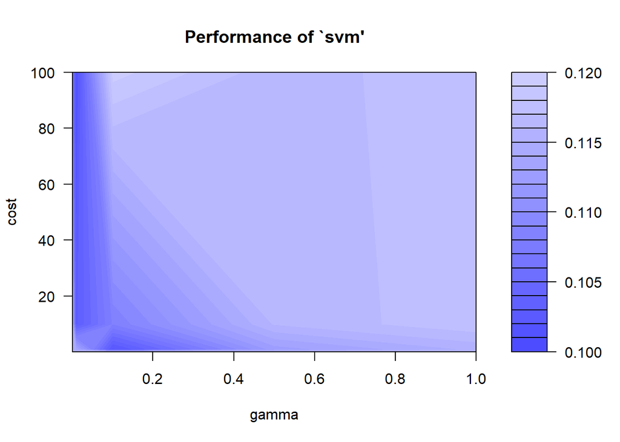

```r
plot(tune_rbf)
```

```r
# Best parameters
cat("\nBest cost for RBF SVM:", tune_rbf$best.parameters$cost)
```

```
##
## Best cost for RBF SVM: 100
```

```r
cat("\nBest gamma for RBF SVM:", tune_rbf$best.parameters$gamma, "\n")
```

```
##
## Best gamma for RBF SVM: 0.01
```

```r
# Train final RBF SVM with best parameters
svm_rbf <- tune_rbf$best.model

# Predictions
pred_rbf <- predict(svm_rbf, newdata = test)
pred_rbf_f <- factor(pred_rbf, levels = levels(test$y))

# Confusion Matrix
cm_rbf <- confusionMatrix(pred_rbf_f, test_y_f)
print(cm_rbf)
```

```
## Confusion Matrix and Statistics
##
##           Reference
## Prediction   0   1
##          0 780  77
##          1  20  27
##
##                Accuracy : 0.8927
##                  95% CI : (0.8707, 0.9121)
##     No Information Rate : 0.885
##     P-Value [Acc > NIR] : 0.2513
##
##                   Kappa : 0.3081
##
##  Mcnemar's Test P-Value : 1.301e-08
##
##             Sensitivity : 0.9750
##             Specificity : 0.2596
##          Pos Pred Value : 0.9102
##          Neg Pred Value : 0.5745
##              Prevalence : 0.8850
##          Detection Rate : 0.8628
##    Detection Prevalence : 0.9480
##       Balanced Accuracy : 0.6173
##
##        'Positive' Class : 0
##
```

```r
# Get decision values for proper AUC calculation
pred_rbf_dv <- predict(svm_rbf, newdata = test, decision.values = TRUE)
scores_rbf <- attr(pred_rbf_dv, "decision.values")[, 1]
```

**Bottom line:** RBF offers more flexibility than the linear kernel and can model nonlinear boundaries — but may overfit without proper tuning.

# 5 Model Evaluation

## 5.1 ROC-AUC Calculation

```r
# Convert target to numeric (0/1) for ROC calculation
test_y_numeric <- as.numeric(as.character(test$y))

roc_linear <- roc(test_y_numeric, scores_linear)
roc_rbf <- roc(test_y_numeric, scores_rbf)

auc_linear <- auc(roc_linear)
auc_rbf <- auc(roc_rbf)

cat("\nLinear SVM ROC-AUC:", round(auc_linear, 4))
```

```
##
## Linear SVM ROC-AUC: 0.8953
```

```r
cat("\nRBF SVM ROC-AUC:", round(auc_rbf, 4), "\n")
```

```
##
## RBF SVM ROC-AUC: 0.8559
```

## 5.2 PR-AUC Calculation

```r
# Need to flip the sign of scores since SVM decision values are oriented opposite
pr_linear <- pr.curve(
  scores.class0 = -scores_linear[test$y == "1"],
  scores.class1 = -scores_linear[test$y == "0"],
  curve = TRUE
)

pr_rbf <- pr.curve(
  scores.class0 = -scores_rbf[test$y == "1"],
  scores.class1 = -scores_rbf[test$y == "0"],
  curve = TRUE
)

cat("\nLinear SVM PR-AUC:", round(pr_linear$auc.integral, 4))
```

```
##
## Linear SVM PR-AUC: 0.5635
```

```r
cat("\nRBF SVM PR-AUC:", round(pr_rbf$auc.integral, 4), "\n")
```

```
##
## RBF SVM PR-AUC: 0.4801
```

## 5.3 ROC Curve Visualization

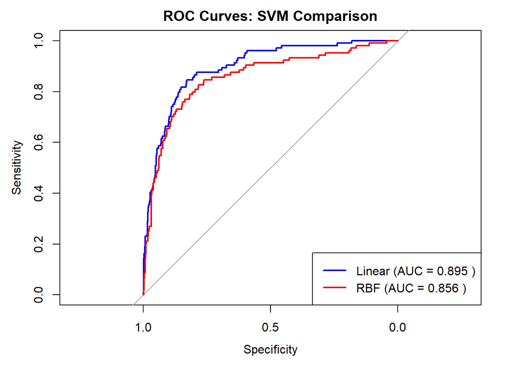

```r
plot(roc_linear, col = "blue", lwd = 2, main = "ROC Curves: SVM Comparison")
plot(roc_rbf, col = "red", lwd = 2, add = TRUE)
legend("bottomright",
       legend = c(paste("Linear (AUC =", round(auc_linear, 3), ")"),
                  paste("RBF (AUC =", round(auc_rbf, 3), ")")),
       col = c("blue", "red"), lwd = 2)
```

## 5.4 PR Curve Visualization

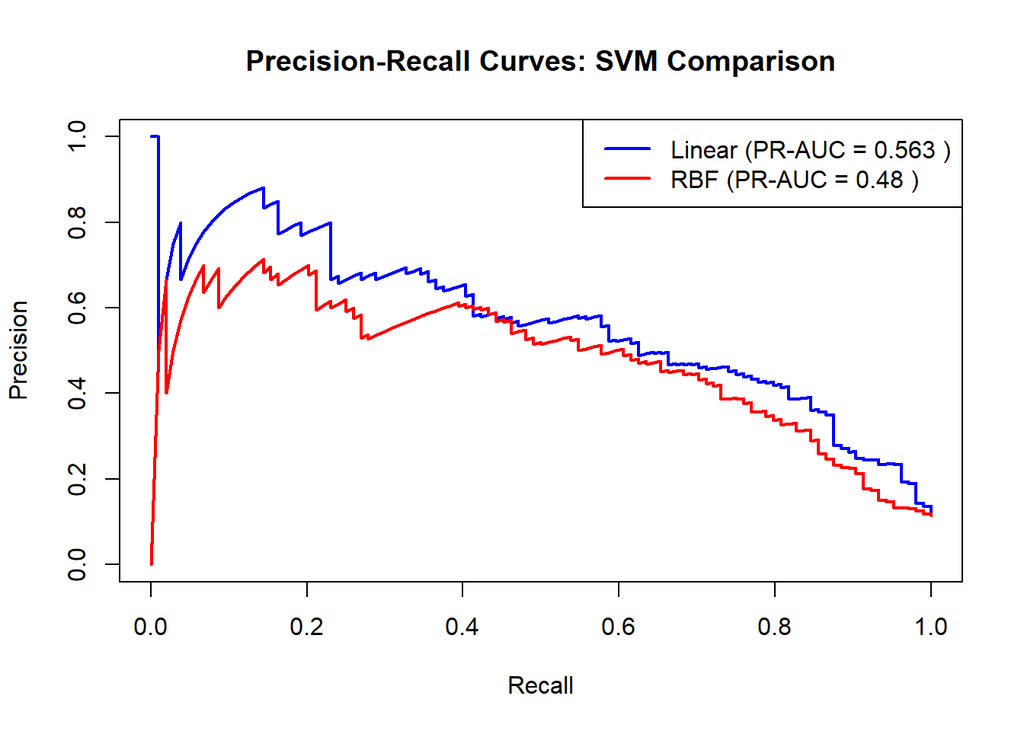

```r
plot(pr_linear, col = "blue", lwd = 2,
     main = "Precision-Recall Curves: SVM Comparison",
     auc.main = FALSE)
plot(pr_rbf, col = "red", lwd = 2, add = TRUE)
legend("topright",
       legend = c(paste("Linear (PR-AUC =", round(pr_linear$auc.integral, 3), ")"),
                  paste("RBF (PR-AUC =", round(pr_rbf$auc.integral, 3), ")")),
       col = c("blue", "red"), lwd = 2)
```

# 6 SVM Model Comparison

```r
model_comp_svm <- tibble(
  Model = c("SVM (Linear)", "SVM (RBF)"),
  Accuracy = c(cm_linear$overall["Accuracy"], cm_rbf$overall["Accuracy"]),
  Sensitivity = c(cm_linear$byClass["Sensitivity"], cm_rbf$byClass["Sensitivity"]),
  Specificity = c(cm_linear$byClass["Specificity"], cm_rbf$byClass["Specificity"]),
  ROC_AUC = c(auc_linear, auc_rbf),
  PR_AUC = c(pr_linear$auc.integral, pr_rbf$auc.integral)
)

kable(model_comp_svm,
      caption = "SVM Model Performance Comparison",
      digits = 4) %>%
  kable_styling(bootstrap_options = c("striped", "hover", "condensed"))
```

SVM Model Performance Comparison

| Model | Accuracy | Sensitivity | Specificity | ROC_AUC | PR_AUC |
| --- | --- | --- | --- | --- | --- |
| SVM (Linear) | 0.8993 | 0.985 | 0.2404 | 0.8953 | 0.5635 |
| SVM (RBF) | 0.8927 | 0.975 | 0.2596 | 0.8559 | 0.4801 |

# 7 Full Comparison with Previous Assignments

```r
# Values from Assignment 2 (actual results)
model_comp_full <- tibble(
  Model = c("Decision Tree", "Random Forest", "AdaBoost",
            "SVM (Linear)", "SVM (RBF)"),
  ROC_AUC = c(
    0.842,
    0.874,
    0.858,
    as.numeric(auc_linear),
    as.numeric(auc_rbf)
  ),
  PR_AUC = c(
    0.510,
    0.667,
    0.630,
    pr_linear$auc.integral,
    pr_rbf$auc.integral
  )
)

kable(model_comp_full,
      caption = "Complete Model Comparison: Assignments 1-3",
      digits = 4) %>%
  kable_styling(bootstrap_options = c("striped", "hover", "condensed")) %>%
  row_spec(4:5, bold = TRUE, color = "white", background = "#3498db")
```

Complete Model Comparison: Assignments 1-3

| Model | ROC_AUC | PR_AUC |
| --- | --- | --- |
| Decision Tree | 0.8420 | 0.5100 |
| Random Forest | 0.8740 | 0.6670 |
| AdaBoost | 0.8580 | 0.6300 |
| SVM (Linear) | 0.8953 | 0.5635 |
| SVM (RBF) | 0.8559 | 0.4801 |

# 8 Key Findings

```r
cat("\n=== KEY FINDINGS ===\n")
```

```
##
## === KEY FINDINGS ===
```

```r
cat("Linear SVM achieved ROC-AUC of", round(auc_linear, 3),
    "with", round(cm_linear$overall["Accuracy"] * 100, 1), "% accuracy\n")
```

```
## Linear SVM achieved ROC-AUC of 0.895 with 89.9 % accuracy
```

```r
cat("RBF SVM achieved ROC-AUC of", round(auc_rbf, 3),
    "with", round(cm_rbf$overall["Accuracy"] * 100, 1), "% accuracy\n")
```

```
## RBF SVM achieved ROC-AUC of 0.856 with 89.3 % accuracy
```

```r
if (auc_linear > auc_rbf) {
  cat("\nLinear kernel outperformed RBF, suggesting feature relationships are largely linear.\n")
} else {
  cat("\nRBF kernel captured nonlinear patterns better than linear kernel.\n")
}
```

```
##
## Linear kernel outperformed RBF, suggesting feature relationships are largely linear.
```